# 1) Introduction: The Crime Analysis task

This section should be written in markdown.

```
1. Give the background to the "Drugs and Guns" project. Use the academic literature to motivate the work. Remember to cite papers you are using.
2. Give the aims and objectives of the project in your own words. (Do not copy the assignment spec)
3. Outline the technical approach (what you plan to do)
```

The role that weapons and drugs play in causing physical harm is both devastating and pervasive. Gun context (e.g., hunting vs. assault weapons) and individual familiarity with weapons are thought to have an impact on this "priming" effect of firearms[2], suggesting a potential degradative effect of this phenomenon among frequent gun users and a heightened potential for weapon effects among societies with lower levels of weapon availability[1]. As drug abuse increases, some people use crimes such as robbery to find items that can be stolen and sold to others to raise money to buy more drugs. Some resort to more serious crimes such as robbery, theft, and extortion. All this is to secure funds for purchasing drugs. Some turn to business to increase their income, but being caught by the police can result in greater penalties by the courts[3]. The firearms that are most commonly used illegally in the UK include pistols, revolvers, and shotguns. Unlawfully modified, reactivated, or converted guns are used in a significant proportion of shootings. This also applies to blank guns with firing modifications. The bulk of shootings in the UK are carried out by street gangs that engage in a variety of criminal activities, including drug dealing and armed robbery[4].

In this notebook, we perform crime analysis using various large datasets such as Street Level Crime Data published by the UK Home Office and English Indices of Deprivation Data. To store and process provided big dataset, we use Microsoft's public cloud computing platform, Microsoft Azure. Big data analysis and visualization are made easy with Spark SQL running on data stored in Azure. Spark's interactive analytics capabilities are fast enough to run exploratory queries without sampling. Combine Spark with visualization tools to interactively process and visualize complex data sets[5]

To evaluate whether the rate of crime is rising or falling, time series analysis, the ADF test, and the stationarity test can be employed. Time-series decomposition can be used to identify the crime's annual trend. Additionally, the correlation may be used to identify a link between drug use and firearm, and the correlation can then be validated through the development of a regression model. Due to its ability to hold records in memory while performing operations, Spark provides exceptional performance for iterative queries typical of machine learning workloads.

# 2) Component Selection and Data Pipeline

In this section you will have one or more code cells. These will include your library imports. You will also access the data efficiently using Apache Spark on a cloud Infrastructure as a Service (IaaS) platform. (NB Google colab is SaaS -- not IaaS)

To speed your subsequent development you may want to initially use a subset of the data so could process that here.

#### Importing

The required libraries have to be imported. Since we are using Python, we must import the Pyspark module to use SparkSession and related libraries. In order to use matplotlib and seaborn for visualisation, pandas were imported so that the spark dataframe could be converted to a pandas dataframe.

```python
import pandas as pd
from pyspark.sql import SparkSession
from pyspark.sql.functions import col,when, count,regexp_extract
from pyspark.sql.functions import sum as _sum
import warnings
import matplotlib.pyplot as plt
from pyspark.sql import Window
warnings.filterwarnings("ignore") # specify to ignore warning messages
import statsmodels.api as sm
import seaborn as sns
from pandas.plotting import scatter_matrix
from pyspark.ml.stat import Correlation
from pyspark.ml.stat import Summarizer
from pyspark.ml.evaluation import RegressionEvaluator
from pyspark.ml import Pipeline
import itertools
from pyspark.ml.feature import VectorAssembler
from pyspark.ml.regression import LinearRegression
```

Here, Spark refers to SparkSession. Each Spark session has a unique name.'KF7032' is set as the name of the session with the 'setAppName' attribute.

```python
spark = SparkSession.builder.appName("KF7032")\
        .config("spark.some.config.option", "some-value").getOrCreate()
```

```python
spark
```

**SparkSession - in-memory**

**SparkContext**

[Spark UI](http://dff88a00bcb5:4040)

**Version**

`v3.1.2`

**Master**

`local[*]`

**AppName**

`KF7032`

### Data preparation

Use the Spark session to read the dataset. The 'csv' function is specified as a parameter in the 'spark.read.format()' since the provided dataset is in CSV format. Spark SQL is used to handle the data, while dataframes are utilised to store the data (together with pandas dataframes for visualisation).

```python
data = "./all_crimes21_hdr.txt.gz"
allcrime = spark.read.load(data, format="csv", header="true", sep=",")
allcrime.show(5)
allcrime.printSchema()
```

```
+--------+-------+--------------------+--------------------+---------+---------+--------------------+---------+--------------------+--------------------+---------------------+-------+
|Crime ID|  Month|         Reported by|        Falls within|Longitude| Latitude|            Location|LSOA code|           LSOA name|          Crime type|Last outcome category|Context|
+--------+-------+--------------------+--------------------+---------+---------+--------------------+---------+--------------------+--------------------+---------------------+-------+
|    null|2010-12|Avon and Somerset...|Avon and Somerset...|-0.805600|51.819143|On or near Norfol...|E01017662| Aylesbury Vale 015C|         Other crime|                 null|   null|
|    null|2010-12|Avon and Somerset...|Avon and Somerset...|-2.494366|51.418169|On or near Keynsh...|E01014399|Bath and North Ea...|Anti-social behav...|                 null|   null|
|    null|2010-12|Avon and Somerset...|Avon and Somerset...|-2.511927|51.409435|On or near Harlec...|E01014399|Bath and North Ea...|Anti-social behav...|                 null|   null|
|    null|2010-12|Avon and Somerset...|Avon and Somerset...|-2.511571|51.414895|On or near Orchar...|E01014399|Bath and North Ea...|Anti-social behav...|                 null|   null|
|    null|2010-12|Avon and Somerset...|Avon and Somerset...|-2.511927|51.409435|On or near Harlec...|E01014399|Bath and North Ea...|Anti-social behav...|                 null|   null|
+--------+-------+--------------------+--------------------+---------+---------+--------------------+---------+--------------------+--------------------+---------------------+-------+
only showing top 5 rows

root
 |-- Crime ID: string (nullable = true)
 |-- Month: string (nullable = true)
 |-- Reported by: string (nullable = true)
 |-- Falls within: string (nullable = true)
 |-- Longitude: string (nullable = true)
 |-- Latitude: string (nullable = true)
 |-- Location: string (nullable = true)
 |-- LSOA code: string (nullable = true)
 |-- LSOA name: string (nullable = true)
 |-- Crime type: string (nullable = true)
 |-- Last outcome category: string (nullable = true)
 |-- Context: string (nullable = true)
```

To guarantee that all of the data has been appropriately loaded, a count has been supplied (should equal 65078250 before being placed in the dataframe for the allcrime dataset and 34753 for the LSOA dataset). Additionally, the number of null values for each column is shown, which aids in providing a general understanding of which columns contain only null values.

```python
#count of total records
allcrime.count()
```

```
65078250
```

```python
#null_values_identifying
allcrime.select([count(when(col(c).isNull() , c)).alias(c) for c in allcrime.columns]).show()
```

```
+--------+-----+-----------+------------+---------+--------+--------+---------+---------+----------+---------------------+--------+
|Crime ID|Month|Reported by|Falls within|Longitude|Latitude|Location|LSOA code|LSOA name|Crime type|Last outcome category| Context|
+--------+-----+-----------+------------+---------+--------+--------+---------+---------+----------+---------------------+--------+
|24242335|    0|          0|           0|   957447|  957447|       0|  2528265|  2528265|         0|             26418132|64955845|
+--------+-----+-----------+------------+---------+--------+--------+---------+---------+----------+---------------------+--------+
```

```python
path = "./LSOA_pop_v2.csv"
lsoa = spark.read.load(path, format="csv", header="true", sep=",")
```

```python
lsoa.count()
```

```
34753
```

```python
lsoa.select([count(when(col(c).isNull() , c)).alias(c) for c in lsoa.columns]).show()
```

```
+----+---------+--------------+-----------+----------------------------------------------+--------------------------------+----------------------------------+-----------------------------------------------+------------------------------------------------------------+---------------------------------…
|date|geography|geography code|Rural Urban|Variable: All usual residents; measures: Value|Variable: Males; measures: Value|Variable: Females; measures: Value|Variable: Lives in a household; measures: Value|Variable: Lives in a communal establishment; measures: Value|Variable: Schoolchild or full-tim…
+----+---------+--------------+-----------+----------------------------------------------+--------------------------------+----------------------------------+-----------------------------------------------+------------------------------------------------------------+---------------------------------…
|   0|        0|             0|          0|                                             0|                               0|                                 0|                                              0|                                                           0|                                 …
+----+---------+--------------+-----------+----------------------------------------------+--------------------------------+----------------------------------+-----------------------------------------------+------------------------------------------------------------+---------------------------------…
```

# 3) Data Extraction and Filtering ...

### includes System running, test and diagnostics,

1. Filter the dataset so that crimes refer to appropriate crimes only
2. To see whether crime cartegories are increasing, you will also need to extract them as a time series.

You should be using diagnostic checks throughout this report.

To assess the Violent crime trend, all crime data were first loaded into a DataFrame, and the various crime types and their associated counts were then filtered out of the dataset.

```python
allcrime.select('Crime type').distinct().show(truncate=False)
```

```
+----------------------------+
|Crime type                  |
+----------------------------+
|Bicycle theft               |
|Public order                |
|Drugs                       |
|Public disorder and weapons |
|Other crime                 |
|Robbery                     |
|Criminal damage and arson   |
|Theft from the person       |
|Shoplifting                 |
|Burglary                    |
|Violent crime               |
|Other theft                 |
|Possession of weapons       |
|Violence and sexual offences|
|Vehicle crime               |
|Anti-social behaviour       |
+----------------------------+
```

```python
crimetype = (allcrime.groupby("Crime type").count().withColumnRenamed("crimetype", "count"))
```

From the list of results, "violence/sex crimes" and "violent crimes" are regarded as violent crimes, and the number of violent crimes by year is calculated.

```python
print(allcrime.filter((col('Crime type')=='Violent crime') |
                                                    (col('Crime type') =='Violence and sexual offences')).count())
crimes = allcrime.select("month").filter((col('Crime type')=='Violent crime') |
                                                    (col('Crime type') =='Violence and sexual offences'))\
    .groupBy("month")\
    .count()\
    .orderBy("month")
print(crimes.show())
```

```
13084759
+-------+-----+
|  month|count|
+-------+-----+
|2010-12|57580|
|2011-01|59823|
|2011-02|56691|
|2011-03|62326|
|2011-04|64299|
|2011-05|63633|
|2011-06|62475|
|2011-07|66572|
|2011-08|63284|
|2011-09|57150|
|2011-10|60076|
|2011-11|56895|
|2011-12|56163|
|2012-01|56324|
|2012-02|50598|
|2012-03|58606|
|2012-04|53415|
|2012-05|59541|
|2012-06|56816|
|2012-07|60199|
+-------+-----+
only showing top 20 rows

None
```

```python
lsoa = lsoa.select(col("geography"),col("geography code"),col("Variable: All usual residents; measures: Value"))
lsoa = lsoa.withColumnRenamed("Variable: All usual residents; measures: Value","resident")
lsoa_df = lsoa.withColumn("geography",regexp_extract(lsoa['geography'], '[a-zA-Z]+',0))
lsoa_df.na.drop()
allcrime_df = allcrime.withColumn("LSOA name",regexp_extract(allcrime['LSOA name'],'[a-zA-Z]+',0))
allcrime_firearm = allcrime_df.select("LSOA code","LSOA name","Crime type").\
                 filter((col('Crime type')=='Possession of weapons') & \
                        (col('Last outcome category')=='Offender sent to prison'))
allcrime_firearm = allcrime_firearm.withColumnRenamed("LSOA name","city")
allcrime_df.na.drop()
allcrime_firearm.show()
```

```
+---------+-------------+--------------------+
|LSOA code|         city|          Crime type|
+---------+-------------+--------------------+
|E01014636|      Bristol|Possession of wea...|
|E01014629|      Bristol|Possession of wea...|
|E01014485|      Bristol|Possession of wea...|
|E01014655|      Bristol|Possession of wea...|
|E01014655|      Bristol|Possession of wea...|
|E01029111|    Sedgemoor|Possession of wea...|
|     null|         null|Possession of wea...|
|E01015728|        Luton|Possession of wea...|
|E01018463|     Cheshire|Possession of wea...|
|E01018467|     Cheshire|Possession of wea...|
|E01012068|Middlesbrough|Possession of wea...|
|E01012266|     Stockton|Possession of wea...|
|E01019217|     Carlisle|Possession of wea...|
|E01019336|         Eden|Possession of wea...|
|E01019440|        Amber|Possession of wea...|
|E01019529| Chesterfield|Possession of wea...|
|E01033387| Chesterfield|Possession of wea...|
|E01033387| Chesterfield|Possession of wea...|
|E01033387| Chesterfield|Possession of wea...|
|E01013547|        Derby|Possession of wea...|
+---------+-------------+--------------------+
only showing top 20 rows
```

```python
firearms = allcrime_firearm.join(lsoa_df,lsoa_df["geography code"]==allcrime_firearm["LSOA code"]).\
                select("city","resident")
print(firearms.show())

firearms_df = firearms.withColumn("residents", _sum("resident") \
  .over(Window.partitionBy("city")))
firearms_crime = firearms_df.select("city","residents").\
            groupBy("city","residents").agg(count("city").alias("count")).orderBy("count", ascending= False)
firearms_crime.show()
```

```
+-------------+--------+
|         city|resident|
+-------------+--------+
|      Bristol|    1496|
|      Bristol|    1477|
|      Bristol|    1817|
|      Bristol|    2365|
|      Bristol|    2365|
|    Sedgemoor|    2520|
|        Luton|    1802|
|     Cheshire|    1482|
|     Cheshire|    2192|
|Middlesbrough|    2369|
|     Stockton|    2435|
|     Carlisle|    1725|
|         Eden|    1723|
|        Amber|    1521|
| Chesterfield|    1492|
| Chesterfield|    1171|
| Chesterfield|    1171|
| Chesterfield|    1171|
|        Derby|    1754|
|        Derby|    2093|
+-------------+--------+
only showing top 20 rows

None
+-----------+---------+-----+
|       city|residents|count|
+-----------+---------+-----+
| Birmingham| 401418.0|  235|
|      Leeds| 354488.0|  203|
|      North| 304124.0|  188|
|  Liverpool| 284799.0|  170|
| Manchester| 288113.0|  157|
|  Sheffield| 258876.0|  156|
|      South| 246418.0|  151|
| Nottingham| 233198.0|  148|
|    Lambeth| 242526.0|  138|
|   Kingston| 219972.0|  130|
|      Derby| 243611.0|  130|
|Westminster| 237903.0|  129|
|   Bradford| 206609.0|  122|
|  Doncaster| 206657.0|  119|
|      Stoke| 189462.0|  114|
|    Cardiff| 169634.0|  110|
|     Newham| 232264.0|  109|
|   Plymouth| 179462.0|  108|
|   Kirklees| 193535.0|  105|
|    Croydon| 193886.0|  105|
+-----------+---------+-----+
only showing top 20 rows
```

```python
firearms_crimes_perhead = firearms_crime.withColumn('perhead',col("count")/col("residents"))
firearms_crimes_perhead.show()
```

```
+-----------+---------+-----+--------------------+
|       city|residents|count|             perhead|
+-----------+---------+-----+--------------------+
| Birmingham| 401418.0|  235|5.854246695464579E-4|
|      Leeds| 354488.0|  203|5.726569023493037E-4|
|      North| 304124.0|  188|6.181689047888361E-4|
|  Liverpool| 284799.0|  170|5.969122082591582E-4|
| Manchester| 288113.0|  157|5.449250814784477E-4|
|  Sheffield| 258876.0|  156|6.026051082371483E-4|
|      South| 246418.0|  151| 6.12779910558482E-4|
| Nottingham| 233198.0|  148|6.346538134975429E-4|
|    Lambeth| 242526.0|  138|5.690111575666115E-4|
|   Kingston| 219972.0|  130|5.909843070936301E-4|
|      Derby| 243611.0|  130| 5.33637643620362E-4|
|Westminster| 237903.0|  129|5.422378028019823E-4|
|   Bradford| 206609.0|  122|  5.9048734566258E-4|
|  Doncaster| 206657.0|  119|5.758333857551402E-4|
|      Stoke| 189462.0|  114|6.017037717325901E-4|
|    Cardiff| 169634.0|  110|6.484549088036596E-4|
|     Newham| 232264.0|  109|4.692935624978472...|
|   Plymouth| 179462.0|  108|6.017987094761008E-4|
|   Kirklees| 193535.0|  105|5.425375255121812E-4|
|    Croydon| 193886.0|  105| 5.41555346956459E-4|
+-----------+---------+-----+--------------------+
only showing top 20 rows
```

```python
allcrime_drug = allcrime_df.select("LSOA code","LSOA name","Crime type").filter(col('Crime type')=='Drugs')
allcrime_drug = allcrime_drug.withColumnRenamed("LSOA name","city")
drug_df = allcrime_drug.join(lsoa_df,lsoa_df["geography"]==allcrime_drug["city"]).\
                select("city","resident")
print(drug_df.show())
```

```
+----+--------+
|city|resident|
+----+--------+
|Bath|    1440|
|Bath|    1991|
|Bath|    1691|
|Bath|    1418|
|Bath|    1550|
|Bath|    1620|
|Bath|    1266|
|Bath|    1372|
|Bath|    1509|
|Bath|    1423|
|Bath|    1571|
|Bath|    1259|
|Bath|    1316|
|Bath|    1468|
|Bath|    1577|
|Bath|    1616|
|Bath|    1897|
|Bath|    1789|
|Bath|    1655|
|Bath|    1350|
+----+--------+
only showing top 20 rows

None
```

```python
drugs_crime = drug_df.withColumn("residents", _sum("resident") \
  .over(Window.partitionBy("city")))
drugs_crime.show()
```

```
+---------+--------+------------+
|     city|resident|   residents|
+---------+--------+------------+
|Worcester|    1408|3.34230912E8|
|Worcester|    1597|3.34230912E8|
|Worcester|    1365|3.34230912E8|
|Worcester|    1481|3.34230912E8|
|Worcester|    1586|3.34230912E8|
|Worcester|    2419|3.34230912E8|
|Worcester|    1971|3.34230912E8|
|Worcester|    1643|3.34230912E8|
|Worcester|    1522|3.34230912E8|
|Worcester|    1486|3.34230912E8|
|Worcester|    1578|3.34230912E8|
|Worcester|    1615|3.34230912E8|
|Worcester|    1689|3.34230912E8|
|Worcester|    1232|3.34230912E8|
|Worcester|    1015|3.34230912E8|
|Worcester|    1446|3.34230912E8|
|Worcester|    1629|3.34230912E8|
|Worcester|    1693|3.34230912E8|
|Worcester|    1580|3.34230912E8|
|Worcester|    1791|3.34230912E8|
+---------+--------+------------+
only showing top 20 rows
```

```python
drugs_crimes = drugs_crime.select("city","residents").\
            groupBy("city","residents").agg(count("city").alias("count")).orderBy("city")
drugs_crimes.show()
drugs_crime_perhead = drugs_crimes.withColumn('drugs_perhead',col("count")/col("residents"))
drugs_crime_perhead.show()
```

```
+-----------+--------------+--------+
|       city|     residents|   count|
+-----------+--------------+--------+
|       Adur|   7.9597782E7|   54642|
|  Allerdale|  2.40476468E8|  149640|
|      Amber|  2.81922245E8|  179790|
|       Arun|  5.14939992E8|  323736|
|   Ashfield|  3.22283409E8|  199578|
|    Ashford|  2.13146492E8|  140946|
|  Aylesbury|   5.9728991E8|  394450|
|    Babergh|   1.1994058E8|   73818|
|    Barking| 1.762994013E9| 1043130|
|     Barnet| 2.936977026E9| 1738851|
|   Barnsley| 1.521665401E9|  967407|
|     Barrow|  1.27189167E8|   90209|
|   Basildon| 1.022377923E9|  644490|
|Basingstoke|  7.48215741E8|  486031|
|  Bassetlaw|  2.17148412E8|  134680|
|       Bath|  4.60633872E8|  300955|
|    Bedford|  6.05191797E8|  395829|
|     Bexley| 1.503804554E9|  946372|
| Birmingham|3.037361177E10|18087534|
|      Blaby|   8.7434865E7|   55860|
+-----------+--------------+--------+
only showing top 20 rows

+-----------+--------------+--------+--------------------+
|       city|     residents|   count|       drugs_perhead|
+-----------+--------------+--------+--------------------+
|       Adur|   7.9597782E7|   54642|6.864764146317545E-4|
|  Allerdale|  2.40476468E8|  149640|6.222646284043061E-4|
|      Amber|  2.81922245E8|  179790|6.377290305701134E-4|
|       Arun|  5.14939992E8|  323736|6.286868470685804E-4|
|   Ashfield|  3.22283409E8|  199578|6.192624082612953E-4|
|    Ashford|  2.13146492E8|  140946|6.612635219912509E-4|
|  Aylesbury|   5.9728991E8|  394450| 6.60399570453149E-4|
|    Babergh|   1.1994058E8|   73818|6.154547526783679E-4|
|    Barking| 1.762994013E9| 1043130|5.916809656233359E-4|
|     Barnet| 2.936977026E9| 1738851|5.920546822826935E-4|
|   Barnsley| 1.521665401E9|  967407|6.357554028397074E-4|
|     Barrow|  1.27189167E8|   90209|7.092506549712681E-4|
|   Basildon| 1.022377923E9|  644490| 6.30383330372442E-4|
|Basingstoke|  7.48215741E8|  486031|6.495867079064834E-4|
|  Bassetlaw|  2.17148412E8|  134680| 6.20220975873404E-4|
|       Bath|  4.60633872E8|  300955|6.533496954822289E-4|
|    Bedford|  6.05191797E8|  395829|6.540554613631024E-4|
|     Bexley| 1.503804554E9|  946372|6.293184825665849E-4|
| Birmingham|3.037361177E10|18087534|5.955015866063399E-4|
|      Blaby|   8.7434865E7|   55860|6.388755789809935E-4|
+-----------+--------------+--------+--------------------+
only showing top 20 rows
```

```python
firearm_drug = drugs_crime_perhead.join(firearms_crimes_perhead,\
                    drugs_crime_perhead["city"]==firearms_crimes_perhead["city"]).\
                select("perhead","drugs_perhead")
firearm_drug = firearm_drug.withColumnRenamed("perhead","firearm_perhead")
firearm_drug.show()
```

```
+--------------------+--------------------+
|     firearm_perhead|       drugs_perhead|
+--------------------+--------------------+
|7.256467081135147E-4|6.378584156811923E-4|
|5.546311702717693E-4|5.960264900662252E-4|
|5.959982971477225E-4|6.286868470685804E-4|
|5.600896143382942E-4|6.333836569663526E-4|
|5.223978059292151E-4| 6.11816029579975E-4|
|5.650426921145153E-4|5.910525080617823E-4|
|5.515719801434088E-4|6.490450924077951E-4|
|5.538376332671805E-4| 6.10884211261214E-4|
|5.274842935646916E-4|5.576013847101054E-4|
|5.879642136375916E-4|6.035797767852244E-4|
|5.857372968223752E-4|6.123207686083553E-4|
|5.616505036132849E-4| 6.21177370030581E-4|
|6.629415664362155E-4|6.542332475959169E-4|
|6.162763583064059E-4|6.394832108560404E-4|
|6.138735420503376E-4|6.281048364072403E-4|
|6.161971830985916E-4|6.237061415149424E-4|
| 5.54793120565305E-4|5.705930601619058E-4|
|6.205398696866273E-4|6.276281930584322E-4|
|6.588235294117648E-4|6.491220349425692E-4|
|5.715218811234487E-4|5.762314463409303E-4|
+--------------------+--------------------+
only showing top 20 rows
```

# 4) Design, Development and reasoning behind use of multiple visualization methods, statistics, and machine learning Models,

The purpose of visualizations is to help identify relationships to investigate more formally, such as with statistics. Consequently you must explain your design choices. That is, what are you expecting to see in your graphics. Support your ideas using the literature.

### Trend Analysis Crime Type with its count

```python
crime_pdf = crimetype.toPandas()
crime_pdf.plot.bar(x='Crime type', y='count', rot=90);
plt.title("crime type vs count")
plt.xlabel("crime type")
plt.ylabel("count")
```

### Yearly trend analysis in crime

The crime analysis with years is represented by the line graph below. Here, the year is represented by the x-axis, while the number of violent crimes is shown by the y-axis. The Month column has to be set as an index and transformed into a DateTime object. Throughout the decade. Crime has shown an increasingly volatile pattern over this period, although it declined slightly in 2013.

```python
crimes_pd = crimes.toPandas()
crimes_pd.month = crimes_pd.month.astype('datetime64[ns]')
crimes_pdf = crimes_pd.set_index(pd.to_datetime(crimes_pd.month))
crimes_pdf.index
plt.figsize=(20, 6)

crimes_pdf.plot(y='count', x='month',marker='.', linestyle='-', linewidth=0.5,\
         subplots=False,
              label='Yearly violance crime volume',
              title='Violance crime Vs year')
plt.ylabel('Violance Crime')
plt.xlabel('Year')
```

### Crime Analysis using Time Series

A trend is the long-term direction of a time series. This component is typically increasing, decreasing, or constant. Seasonality is the periodic behaviour of a time series that occurs within a year. Residuals represent what is behind seasonality and trend decoupling from a time series. In other words, what the model cannot explain is the variability in the data[7]. We can automatically decompose the time series using the seasonal decompose function from statsmodels package.

[figure not shown]

[figure not shown]

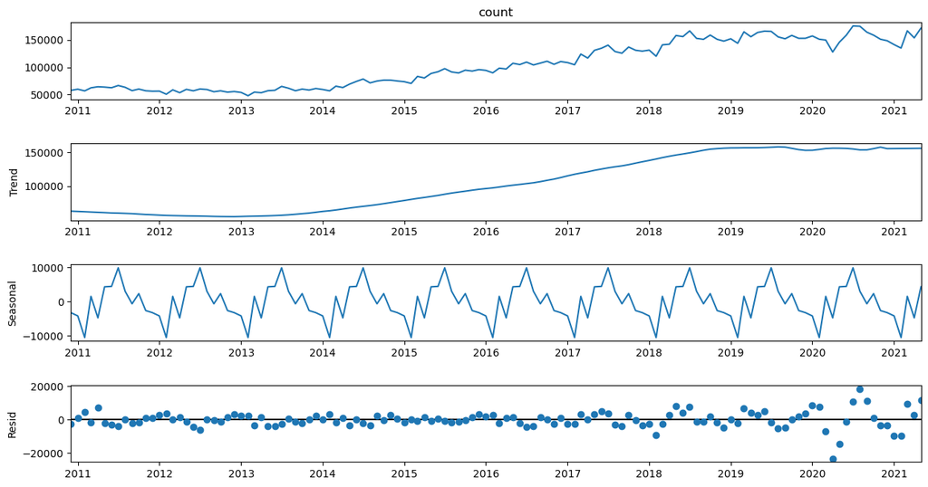

```python
decomposition = sm.tsa.seasonal_decompose(crimes_pdf['count'], model='additive',extrapolate_trend='freq')
fig = decomposition.plot()
fig.set_size_inches(14,7)
plt.show()
```

Decomposition gives a very clear picture of trends and makes time series interpretation easier and more reliable. As we saw with the line plot before, there is a very slight decrease in violent crimes from 2011 to 2013, after which there is a continuous rise until 2019. Following that, we see that violent crime tends to stabilise until the conclusion of the research period in 2021.

### Time Series Plot with Rolling Average

When plotting time series data, these fluctuations can obscure the peaks and troughs of the plot. So, in order to draw distinct values from the data, we use the concept of rolling average concept to create a time series graph. The simple mean of the most recent "n" data is the rolling average or moving average. It can assist us in identifying tendencies that might otherwise be difficult to locate. They can also be employed to identify long-term patterns. The rolling average may be calculated by adding together the past 'n' values and dividing them by 'n'. In contrast, Nan would be the first (n-1) value of the rolling average[6].

```python
def stationarity(timeseries, title):
    plt.clf()
    #Determing rolling statistics
    rolmean = pd.Series(timeseries).rolling(window=10).mean()
    rolstd = pd.Series(timeseries).rolling(window=10).std()

    fig, ax = plt.subplots(figsize=(16, 4))
    ax.plot(timeseries, label= title)
    ax.plot(rolmean, label='rolling mean');
    ax.plot(rolstd, label='rolling std (x10)');
    ax.legend()
    plt.show()
```

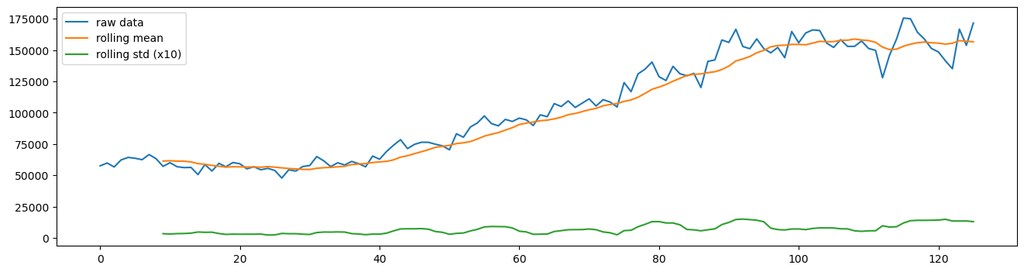

```python
pd.options.display.float_format = '{:.8f}'.format
stationarity(crimes_pd['count'],'raw data')
```

# 5) Selection, application, and reasoning behind use of statistical analysis and multiple evaluation measures

As in the previous section,

1. Explain what you are trying to do (with references)
2. Do the coding and include the results
3. Explain your findings.

### Evaluating firearms incident per head in Birmingham

To visualize the number of firearm incidents per capita, the data frame is converted to pandas.

```python
firearms_crimes_perhead.show()
```

```
+-----------+---------+-----+--------------------+
|       city|residents|count|             perhead|
+-----------+---------+-----+--------------------+
| Birmingham| 401418.0|  235|5.854246695464579E-4|
|      Leeds| 354488.0|  203|5.726569023493037E-4|
|      North| 304124.0|  188|6.181689047888361E-4|
|  Liverpool| 284799.0|  170|5.969122082591582E-4|
| Manchester| 288113.0|  157|5.449250814784477E-4|
|  Sheffield| 258876.0|  156|6.026051082371483E-4|
|      South| 246418.0|  151| 6.12779910558482E-4|
| Nottingham| 233198.0|  148|6.346538134975429E-4|
|    Lambeth| 242526.0|  138|5.690111575666115E-4|
|   Kingston| 219972.0|  130|5.909843070936301E-4|
|      Derby| 243611.0|  130| 5.33637643620362E-4|
|Westminster| 237903.0|  129|5.422378028019823E-4|
|   Bradford| 206609.0|  122|  5.9048734566258E-4|
|  Doncaster| 206657.0|  119|5.758333857551402E-4|
|      Stoke| 189462.0|  114|6.017037717325901E-4|
|    Cardiff| 169634.0|  110|6.484549088036596E-4|
|     Newham| 232264.0|  109|4.692935624978472...|
|   Plymouth| 179462.0|  108|6.017987094761008E-4|
|    Croydon| 193886.0|  105| 5.41555346956459E-4|
|   Kirklees| 193535.0|  105|5.425375255121812E-4|
+-----------+---------+-----+--------------------+
only showing top 20 rows
```

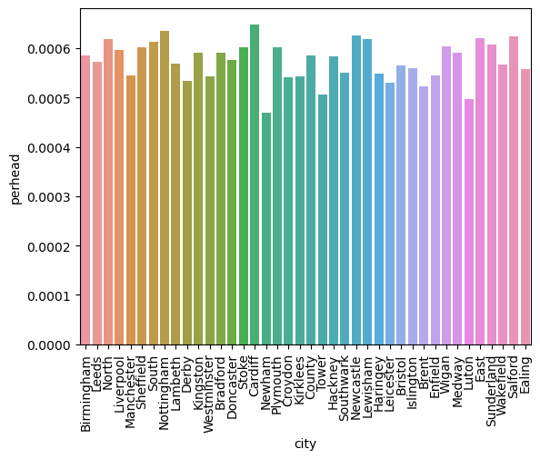

```python
firearms_pd = firearms_crimes_perhead.toPandas()
g = sns.barplot(x="city", y="perhead", data=firearms_pd.head(40))
sns.set_style("darkgrid" , {"ytick.major.size": 10 , "ytick.minor.size": 2 , 'grid.linestyle': '--'})
g.tick_params(axis='x', rotation=90)
plt.show()
```

```python
Birmingham = firearms_pd.loc[firearms_pd['city'] == 'Birmingham' ]
```

According to the visualization, Birmingham is not the city with the highest number of gun incidents per capita.

### Correlation between Drugs and Firearms

An matrix of scatter plots is known as a scatter plot matrix, and it is used to show bivariate correlations between sets of variables. Many associations may be investigated in one chart thanks to the scatter plots in the matrix, which each show the relationship between a pair of variables.

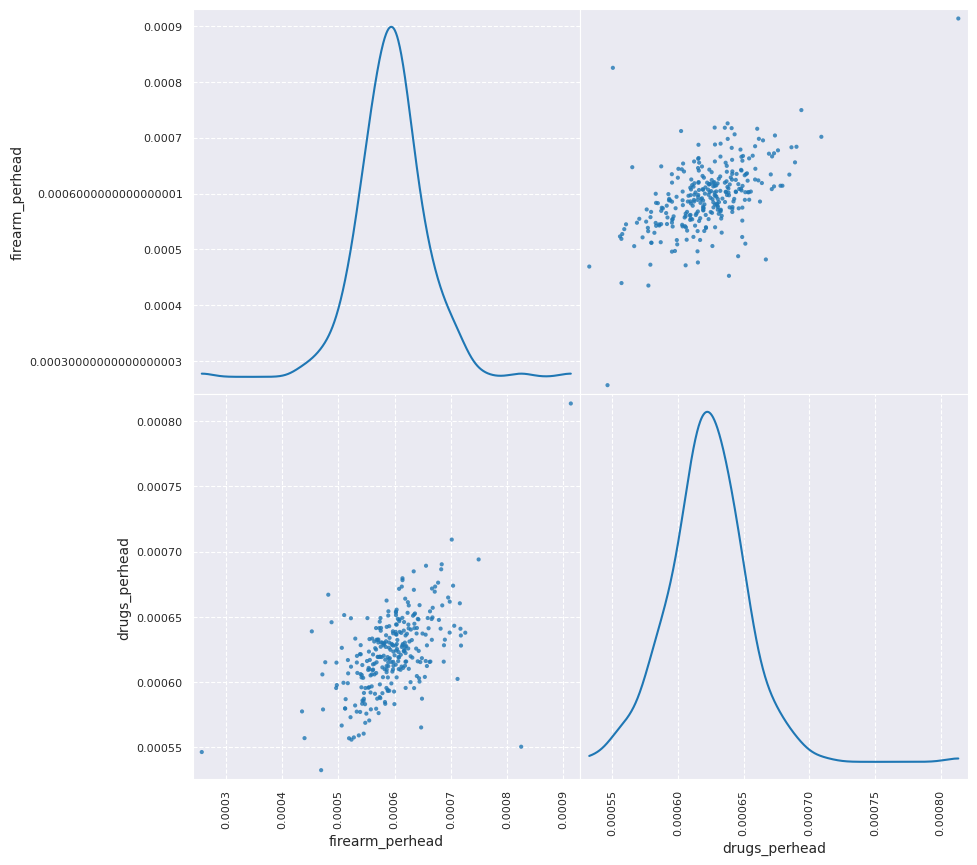

```python
firearm_drug_pdf = firearm_drug.toPandas()
scatter_matrix(firearm_drug_pdf, alpha=0.8, figsize=(10, 10), diagonal='kde')
plt.show()
```

```python
# Vectorize dataframe
vector_col = "corr_features"
assembler = VectorAssembler(inputCols=firearm_drug.columns, outputCol=vector_col)
df_vector = assembler.transform(firearm_drug).select(vector_col)
df_vector.show(5)
```

```
+--------------------+
|       corr_features|
+--------------------+
|[7.25646708113514...|
|[5.54631170271769...|
|[5.95998297147722...|
|[5.60089614338294...|
|[5.22397805929215...|
+--------------------+
only showing top 5 rows
```

```python
cor_np = firearm_drug.stat.corr('firearm_perhead',"drugs_perhead")
cor_np
```

```
0.5619892198188187
```

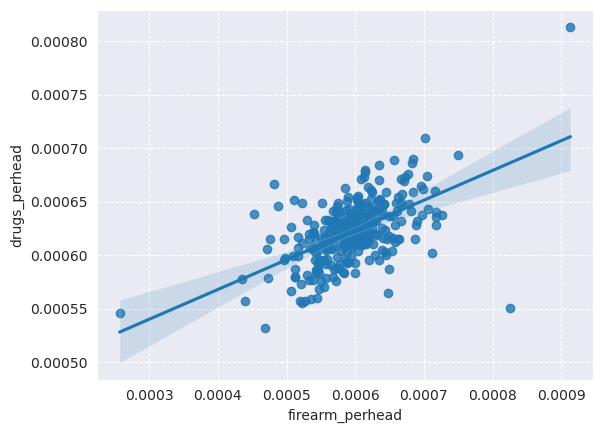

```python
sns.regplot(x='firearm_perhead',y='drugs_perhead', data=firearm_drug_pdf, dropna=True)
plt.show()
```

Correlation coefficients range from -1 to 1, with values closer to 1 indicating a stronger positive correlation. Thus, the visualization plot shows that the drug incidents per capita and his gun incidents per capita are positively correlated.

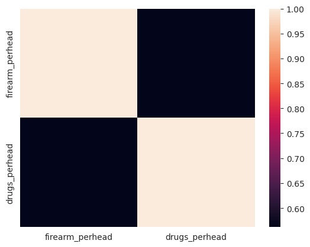

```python
sns.heatmap(firearm_drug_pdf.corr())
plt.show()
```

```python
traindf ,testdf = firearm_drug.randomSplit([.8,.2],seed=42)
print("there are {0} rows in the training set and {1} in the test set ".format(traindf.count(),testdf.count()))
```

```
there are 237 rows in the training set and 56 in the test set
```

```python
vecAssembler = VectorAssembler(inputCols = ["firearm_perhead"],outputCol = "features")
vecTrainDf = vecAssembler.transform(traindf)
vecTrainDf.select("firearm_perhead","features","drugs_perhead").show()
```

```
+--------------------+--------------------+--------------------+
|     firearm_perhead|            features|       drugs_perhead|
+--------------------+--------------------+--------------------+
|7.256467081135147E-4|[7.25646708113514...|6.378584156811923E-4|
|5.600896143382942E-4|[5.60089614338294...|6.333836569663526E-4|
|5.223978059292151E-4|[5.22397805929215...| 6.11816029579975E-4|
|5.650426921145153E-4|[5.65042692114515...|5.910525080617823E-4|
|5.274842935646916E-4|[5.27484293564691...|5.576013847101054E-4|
|5.515719801434088E-4|[5.51571980143408...|6.490450924077951E-4|
|5.616505036132849E-4|[5.61650503613284...| 6.21177370030581E-4|
|5.857372968223752E-4|[5.85737296822375...|6.123207686083553E-4|
|5.879642136375916E-4|[5.87964213637591...|6.035797767852244E-4|
|6.629415664362155E-4|[6.62941566436215...|6.542332475959169E-4|
|6.162763583064059E-4|[6.16276358306405...|6.394832108560404E-4|
|6.138735420503376E-4|[6.13873542050337...|6.281048364072403E-4|
|6.161971830985916E-4|[6.16197183098591...|6.237061415149424E-4|
|6.205398696866273E-4|[6.20539869686627...|6.276281930584322E-4|
|5.715218811234487E-4|[5.71521881123448...|5.762314463409303E-4|
|5.757475530728995E-4|[5.75747553072899...|6.304531749687223E-4|
|5.959870207271041E-4|[5.95987020727104...|6.080572118307968E-4|
|6.588235294117648E-4|[6.58823529411764...|6.491220349425692E-4|
|5.752085130859936E-4|[5.75208513085993...|6.270752593110396E-4|
|6.079584256375235E-4|[6.07958425637523...|6.714917279478487E-4|
+--------------------+--------------------+--------------------+
only showing top 20 rows
```

```python
lr = LinearRegression(featuresCol="features", labelCol="drugs_perhead")
lrModel = lr.fit(vecTrainDf)
```

```python
pipeline = Pipeline(stages=[vecAssembler, lr])
pipelineModel = pipeline.fit(traindf)
```

```python
pipeline = Pipeline(stages=[vecAssembler, lr])
pipelineModel = pipeline.fit(traindf)
```

```python
predDF = pipelineModel.transform(testdf)
predDF.select("firearm_perhead","features","drugs_perhead","prediction").show()
```

```
+--------------------+--------------------+--------------------+--------------------+
|     firearm_perhead|            features|       drugs_perhead|          prediction|
+--------------------+--------------------+--------------------+--------------------+
|5.546311702717693E-4|[5.54631170271769...|5.960264900662252E-4|6.112651701273783E-4|
|5.959982971477225E-4|[5.95998297147722...|6.286868470685804E-4|6.226339304462303E-4|
|5.538376332671805E-4|[5.53837633267180...| 6.10884211261214E-4|6.110470855590117E-4|
| 5.54793120565305E-4|[5.54793120565305...|5.705930601619058E-4|6.113096782721255E-4|
|5.857087075361187E-4|[5.85708707536118...|6.075834654913187E-4|6.198060841124867E-4|
|6.621054954756124E-4|[6.62105495475612...|6.154547526783679E-4|6.408019046300377E-4|
|4.726344645051517E-4|[4.72634464505151...|5.790315068665584E-4|5.887303468221126E-4|
|6.361753678311834E-4|[6.36175367831183...| 6.52615517542489E-4|6.336756324305991E-4|
|4.766094735298430...|[4.76609473529843...|6.152195860676426E-4|5.898227824897503E-4|
| 6.87757909215956E-4|[6.87757909215956...|6.282459373429386E-4| 6.47851853839431E-4|
|5.615750528541226E-4|[5.61575052854122...|6.136080151289583E-4| 6.13173529317944E-4|
|4.397344004221450...|[4.39734400422145...|5.570490929787595E-4|5.796885551560831E-4|
|5.168849069607167E-4|[5.16884906960716...|6.169031462060457E-4|6.008915171105164E-4|
|6.284367635506677E-4|[6.28436763550667...|6.198078595635353E-4|6.315488630871191E-4|
|5.806845965770171E-4|[5.80684596577017...|6.293266205160479E-4| 6.18425327999532E-4|
|6.713340366356574E-4|[6.71334036635657...|6.693331156640274E-4|6.433381473054313E-4|
|5.843239975821076E-4|[5.84323997582107...|6.269536721254619E-4|6.194255298713017E-4|
|5.327650506126798E-4|[5.32765050612679...|6.150208867482967E-4|6.052557928202965E-4|
|6.558237145855194E-4|[6.55823714585519...|6.891877921869077E-4|6.390755081720685E-4|
| 5.29732654073306E-4|[5.29732654073306...|5.821021771227781E-4|6.044224115329946E-4|
+--------------------+--------------------+--------------------+--------------------+
only showing top 20 rows
```

```python
regressionEvaluator = RegressionEvaluator(
 predictionCol="prediction",
 labelCol="drugs_perhead",
 metricName="rmse")
r2 = regressionEvaluator.setMetricName("r2").evaluate(predDF)
print("R2 is {}".format(r2))
```

```
R2 is 0.3408587582229634
```

R2 is the percentage of variation in the dependent variable that can be predicted from the independent variables. The model is not suitable for use in forecasting. The model can be improved by including more influential features.

# 6) Detailed Analysis and consideration of the appropriateness of the solution for the initial problem

This is the discussion section of you report. You should critically consider the advantages, disadvantages, and limitations of the methods used.

To assess the claim that Birmingham has more shootings per capita than anywhere else in the UK, The firearm incident count is evaluated by aggregating by city and this number is divided by the total population in each city to generate the necessary feature. utilised the seaborn package, which is superior to matplotlib in handling Pandas data frames and representing graphs more attractively, to visualise the data.

Investigation of the connection between drug offences and firearm events is done using linear regression analysis.Similar to how drug incidents are analysed, the number of firearm incidents is aggregated by city and divided by each city's total population before being used to determine the number of incidents. The Regression line scatter plot is used to representing that these features are correlated.A linear regression model was created in the end to validate the association. However, the R2 score is less than 0.7, indicating that the predictive model is poor.

# 7) Evaluation and Conclusion *markdown*,

In the conclusion you should consider you initial aim and objectives and discuss your findings. Specifically you need to advice your client insurance company.

# 8) References and Citation *markdown*,

References are essential at level 7. in this section you should give references for the papers/books you have cited in this assignment. Try to avoid using web pages as these are considered *weak references* as they are often not reviewed.

1. I. R. Brennan and S. C. Moore, “Weapons and violence: A review of theory and research,” Aggression and Violent Behavior, vol. 14, no. 3, pp. 215–225, 2009.
2. C. A. Anderson, N. L. Carnagey, M. Flanagan, A. J. Benjamin, J. Eubanks, and J. C. Valentine, “Violent video games: Specific effects of violent content on aggressive thoughts and behavior,” Advances in Experimental Social Psychology, pp. 199–249, 2004.
3. “Drugs and crime,” nidirect, 02-Jul-2021. [Online]. Available: https://www.nidirect.gov.uk/articles/drugs-and-crime.
4. Panlogic, “Illegal firearms,” National Crime Agency, 15-Dec-2022. [Online]. Available: [https://www.nationalcrimeagency.gov.uk/what-we-do/crime-threats/firearms#:~:text=Know%20the%20law%3A%20It's%20illegal,111%20to%20stay%20100%25%20anonymous](https://www.nationalcrimeagency.gov.uk/what-we-do/crime-threats/firearms#:~:text=Know%20the%20law%3A%20It%27s%20illegal,111%20to%20stay%20100%25%20anonymous).
5. S. Q. L. S. Team, “Eight scenarios with Apache Spark on azure that will transform any business,” Microsoft SQL Server Blog, 20-Sep-2021. [Online]. Available: https://cloudblogs.microsoft.com/sqlserver/2016/08/29/eight-scenarios-with-apache-spark-on-azure-that-will-transform-any-business/.
6. J. S. Damji, B. Wenig, T. Das, and D. G.-Y. Lee, Learning spark: Lightning-fast big data analytics. Sebastopol, CA: O'Reilly, 2020.
7. T. C. Mills, Applied Time Series Analysis: A practical guide to modeling and forecasting. London: Academic Press, 2019.